# Clusterization and classification of hepatitis dataset

Monika Zakrzewska

# 1 Descriptive analysis and visualization

This report will describe a *hepatitis* dataset downloaded from the UCI Machine Learning open repository. The dataset describes patients who have undergone hepatitis. Initially, we will consider the association of variables due to survival. There are 14 categorical variables in the dataset (Class, Sex, Steroid, Antivirals, Fatigue, Malaise, Anorexia, Liver Big, Liver Firm, Spleen Palpable, Spiders, Ascites, Varices) and 6 quantitative variables (Age, Bilirubin, Alk Phosphate, SGOT, Albumin, Protime). The data (especially the quantitative variables) have missing records. To fill in the missing records in quantitative variables, the median will be used and in the categorical variables it will be the mode (the most commonly used data).

In the database, the empty records had a value of *“?”* which was converted to *NA* while loading the data into RStudio.

The question we want to answer in this analysis is whether age, gender, psychology (fatigue, malaise, anorexia) and the amount of bilirubin (a bile pigment that comes from the breakdown of red blood cells, its concentration in the blood helps to assess liver function - an increase in this concentration can cause jaundice) affected survival. This subset will be called *hepatitis1* and will be used in the rest of the document - for clusterization and classification.

Below we chnage the names of columns and recode categorical variables.

```r
colnames(hepatitis) <- c("Class", "AGE", "SEX", "STEROID", "ANTIVIRALS", "FATIGUE",
                         "MALAISE", "ANOREXIA", "LIVER BIG", "LIVER FIRM",
                         "SPLEEN PALPABLE", "SPIDERS", "ASCITES", "VARICES",
                         "BILIRUBIN", "ALK_PHOSPHATE", "SGOT", "ALBUMIN",
                         "PROTIME", "HISTOLOGY")

hepatitis$SEX[hepatitis$SEX == "1"] <- "M"
hepatitis$SEX[hepatitis$SEX == "2"] <- "F"

hepatitis$Class[hepatitis$Class == "1"] <- "DIE"
hepatitis$Class[hepatitis$Class == "2"] <- "LIVE"

hepatitis[4:14][hepatitis[,c(4:14)] == 1] <- 0
hepatitis[4:14][hepatitis[,c(4:14)] == 2] <- 1
hepatitis[20][hepatitis[20] == 1] <- 0
hepatitis[20][hepatitis[20] == 2] <- 1

hepatitis1 <- data.frame(hepatitis[1:3], hepatitis[6:8], hepatitis[15])
```

The gender variables from *1* and *2* were changed to *M* and *F* respectively, in the Class variable *1* means *DIE* and *2* means *LIVE*. The qualitative data were then changed from *1* to *0* and from *2* to *1* in all data.

Initially, all the data will be analysed, but the results will only be presented for selected ones involved in the analysis (Class, age, fatigue, malaise, anorexia and bilirubin).

A general description will be given below for orientation, i.e. how many variables we have, how many complete rows, etc.

```
##                       [,1]
## rows                   155
## columns                  7
## discrete_columns         2
## continuous_columns       5
## all_missing_columns      0
## total_missing_values     9
## complete_rows          149
## total_observations    1085
## memory_usage         11216
```

It is seen that there are 155 observations (patients) with only 9 missing cells (out of 1085), so it is not a big deficiency.

Below there is a chart that shows how the missing data is distributed across the group.

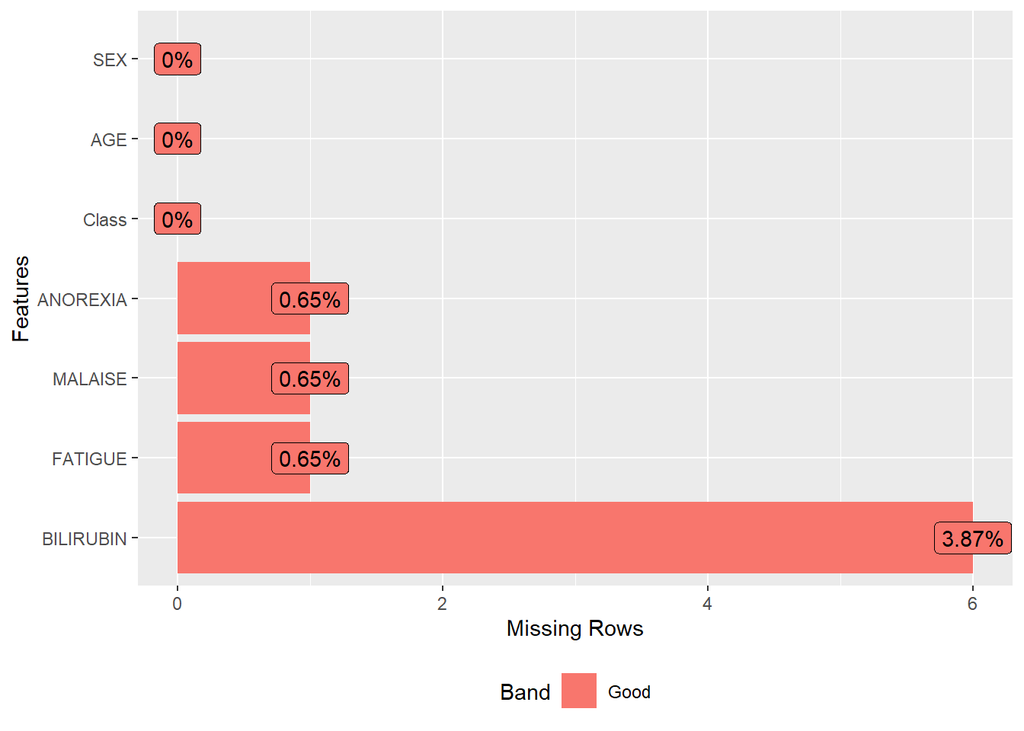

Missing data distribution

As it is seen, there is not much missing data, but for the accuracy of the analysis and the lack of deletion of records, they will be supplemented with an median or mode.

## 1.1 Quantitative variables

As can be seen above Bilirubin is the only quantitative variable to have missing data. Therefore, these missing data will be replaced by median.

```r
hepatitis1 <- hepatitis1 %>%
  replace_na(list(BILIRUBIN = median(na.omit(hepatitis1$BILIRUBIN))))
```

Below are descriptive statistics and measures of position and spread for the quantitative variables considered.

Descriptive statistics for quantitative variables

|  | AGE | BILIRUBIN |
| --- | --- | --- |
| Mean | 41.20 | 1.41 |
| Std.Dev | 12.57 | 1.19 |
| Min | 7.00 | 0.30 |
| Q1 | 32.00 | 0.80 |
| Median | 39.00 | 1.00 |
| Q3 | 50.00 | 1.50 |
| Max | 78.00 | 8.00 |
| MAD | 13.34 | 0.44 |
| IQR | 18.00 | 0.70 |
| CV | 0.30 | 0.84 |
| Skewness | 0.36 | 2.91 |
| SE.Skewness | 0.19 | 0.19 |
| Kurtosis | -0.18 | 10.24 |
| N.Valid | 155.00 | 155.00 |
| Pct.Valid | 100.00 | 100.00 |

It can be seen that the average age of the individuals in the analysis under consideration a little bit over $41$ years, so they are middle-aged. It can also be seen that there may be outliers in the case of bilirubin, which will be diagnosed and addressed in the following subsections.

Descriptive statistics for patients that survived and for patients that died

|  | Survived AGE | Survived BILIRUBIN | Died AGE | Died BILIRUBIN |
| --- | --- | --- | --- | --- |
| Mean | 39.80 | 1.14 | 46.59 | 2.45 |
| Std.Dev | 12.83 | 0.71 | 9.94 | 1.91 |
| Min | 7.00 | 0.30 | 30.00 | 0.40 |
| Q1 | 30.00 | 0.70 | 38.50 | 1.00 |
| Median | 38.00 | 1.00 | 46.50 | 1.80 |
| Q3 | 50.00 | 1.20 | 55.00 | 3.40 |
| Max | 78.00 | 4.60 | 70.00 | 8.00 |
| MAD | 11.86 | 0.44 | 11.86 | 1.26 |
| IQR | 20.00 | 0.50 | 15.75 | 2.15 |
| CV | 0.32 | 0.62 | 0.21 | 0.78 |
| Skewness | 0.51 | 2.79 | 0.29 | 1.35 |
| SE.Skewness | 0.22 | 0.22 | 0.41 | 0.41 |
| Kurtosis | -0.02 | 9.00 | -0.72 | 1.27 |
| N.Valid | 123.00 | 123.00 | 32.00 | 32.00 |
| Pct.Valid | 100.00 | 100.00 | 100.00 | 100.00 |

- Box plots for the data considered by class:

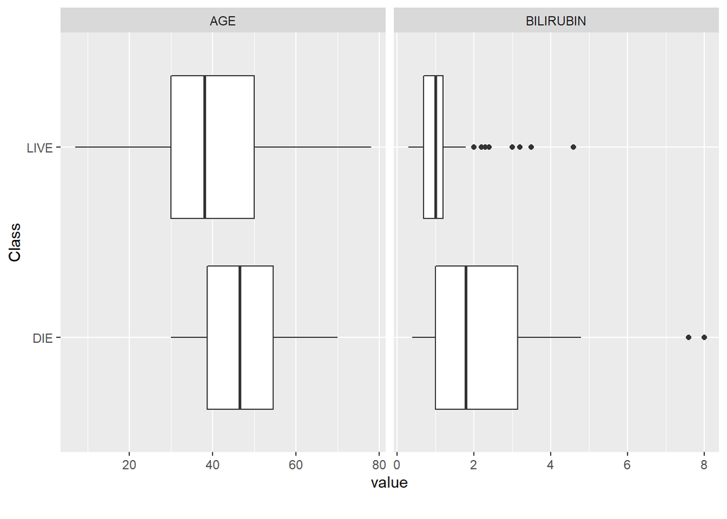

Box plots for the data considered by class

In both cases, bilirubin has outlier observations. Class “LIVE” have more of them. To replace those outliers, median value will be assigned in a place of the outlier.

```r
sapply(hepatitis1$BILIRUBIN, function(x) x %in% boxplot(hepatitis1$BILIRUBIN, plot = FALSE)$out)

hepatitis1$BILIRUBIN[hepatitis1$BILIRUBIN %in% boxplot(hepatitis1$BILIRUBIN, plot = FALSE)$out] <- median(hepatitis1$BILIRUBIN)
```

- Distributions of quantitative variables:

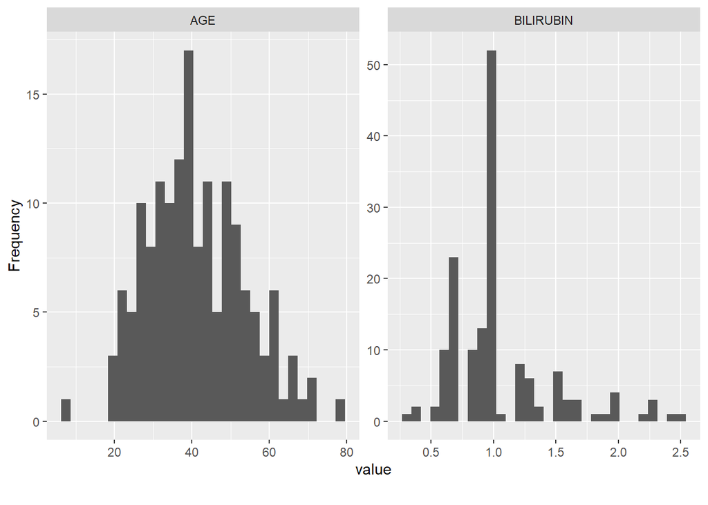

Distributions of quantitative variables

The distribution graph for bilirubin looks like this due to the fact that there were quite a few outlier observations that were converted into a median. The distribution for age gently resembles a normal distribution, whereas the distribution for bilirubin does not.

- Densities:

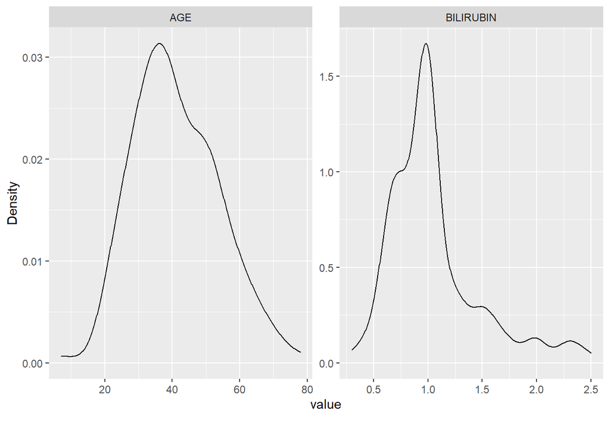

Density plots of quantitative variables

The density of the AGE variable also resembles a normal distribution (as does the histogram), so one can check that the data come from a normal distribution. This will also be checked for bilirubin (but it is already clear from the histogram and density plot that the sample is not from a normal distribution).

Shapiro-Wilk test results for quantitative variables

|  | W.statistics | p.value |
| --- | --- | --- |
| AGE | 0.98 | 0.08 |
| BILIRUBIN | 0.86 | 0.00 |

The p-value for age is greater than the standard significance level ($\alpha = 0.05$), so there is no basis to reject the null hypothesis that the sample comes from a normal distribution. For bilirubin the p-value is less than the standard significance level, so we can reject the null hypothesis in favour of the alternative hypothesis, that the sample is not from a normal distribution.

- QQ-plot:

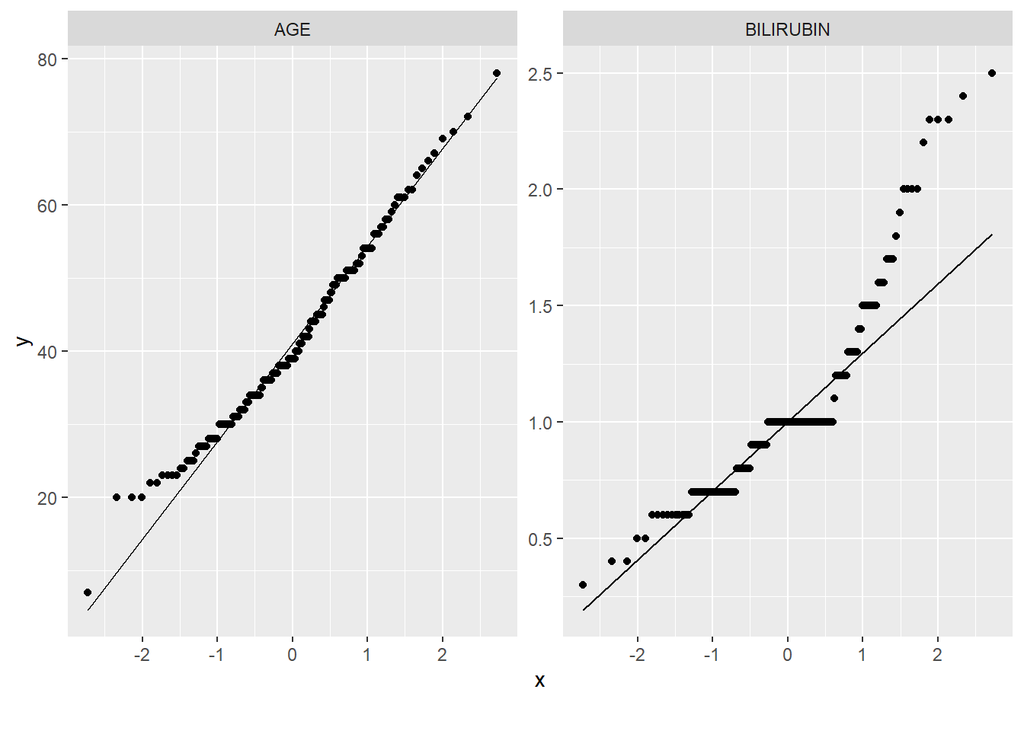

QQ plots of quantitative variables

In the qq plots, it is clear that the ages arrange themselves into a straight line, which may suggest that the sample comes from a normal distribution. The bilirubin values do not arrange themselves into a straight line, indeed they have ‘levels’ that may have arisen when the outliers were turned into the median.

- Correlations:

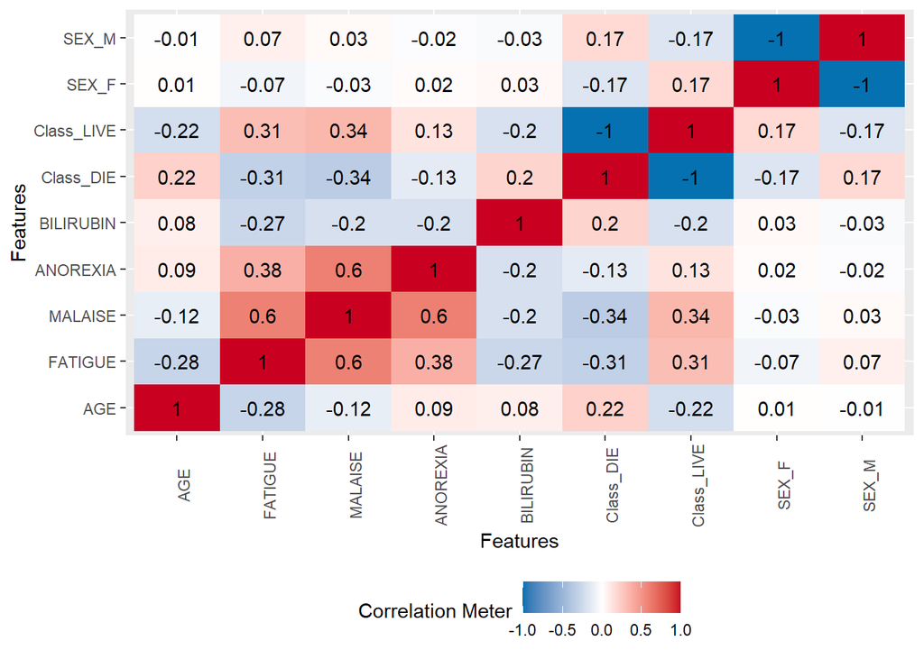

Correlations plot

From the graph, it can be seen that a medium ($\rho \in (0.4, 0.7)$) correlation occurs between malaise and fatigue and between malaise and anorexia. Strong and very strong correlations do not occur between these data. The rest of the variables have weak or very weak correlations between them.

- Data spread:

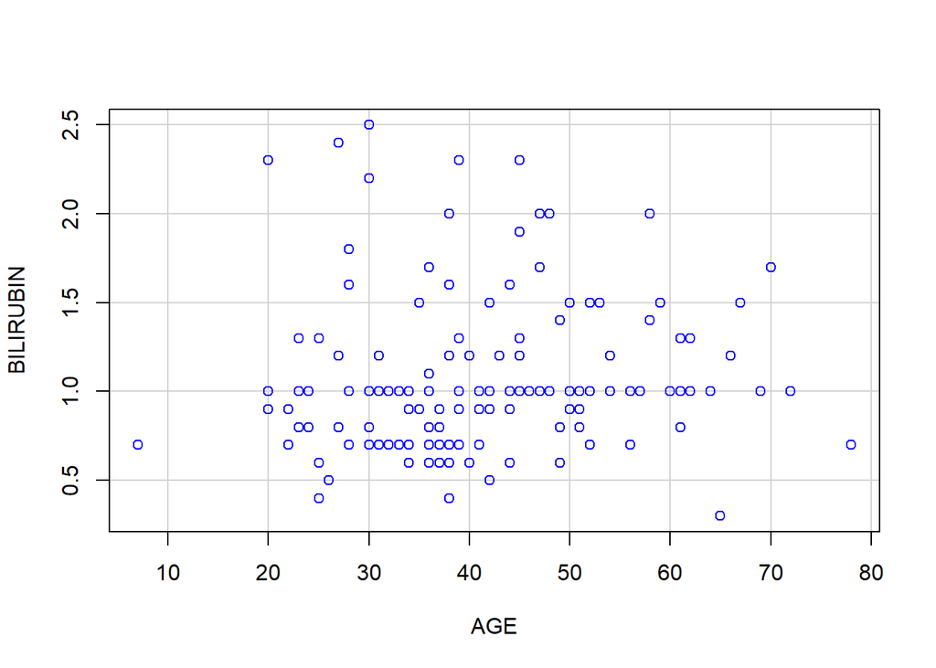

Scatterplot of AGE and BILIRUBIN

A scatterplot shows that there is no apparent trend or correlation between age and bilirubin levels.

## 1.2 Qualitative variables

To replace missing data, mode will be used.

```r
mode <- function(x){
  distinct_values <- unique(x)
  distinct_tabulate <- tabulate(match(x, distinct_values))
  distinct_values[which.max(distinct_tabulate)]
}

hepatitis1 <- hepatitis1 %>%
  mutate(across(everything(), ~replace_na(.x, mode(.x))))
```

Below there are frequency tables for the variables considered as categorical.

Frequency table of categorical variables by class

| label | variable | Class DIE | Class LIVE |
| --- | --- | --- | --- |
| SEX | F | 0 (0%) | 16 (100.00%) |
|  | M | 32 (23.02%) | 107 (76.98%) |
| FATIGUE | 0 | 30 (29.70%) | 71 (70.30%) |
|  | 1 | 2 (3.70%) | 52 (96.30%) |
| MALAISE | 0 | 23 (37.70%) | 38 (62.30%) |
|  | 1 | 9 (9.57%) | 85 (90.43%) |
| ANOREXIA | 0 | 10 (31.25%) | 22 (68.75%) |
|  | 1 | 22 (17.89%) | 101 (82.11%) |

Below there is a graph of what survival looks like depending on whether there was malaise. Nearly $40\%$ of people who did not have malaise died, and of those patients who had malaise, more than $90\%$ survived, which may suggest that people with good wellbeing were more likely to die than those with malaise.

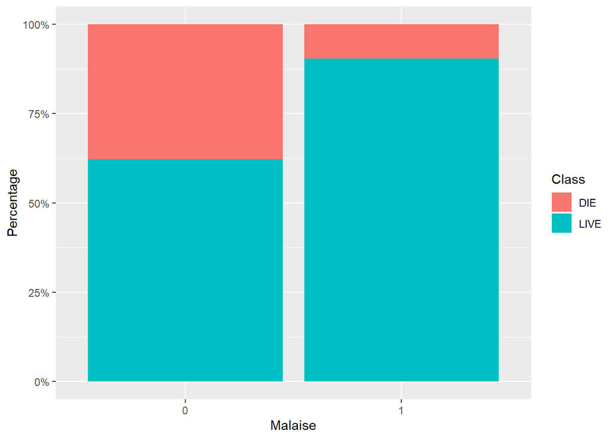

Barplot of Malaise by group and class

Now, when the data exploration is over, let’s get to the clusterization.

# 2 Clusterization

## 2.1 Methods

The clustering methods/algorithms that will be used are:

- **PAM** - a generalised version of the k-means algorithm. It can be used for mixed type data (qualitative and quantitative variables) and is more robust to outlier observations than the k-means metdoa. As in the k-means method, the number of clusters must be specified at the beginning.
- **AGNES** - belongs to agglomerative methods, which means that each observation is initially treated as a separate cluster. In subsequent stages, groups that are similar to each other are combined into larger and larger groups until an all-encompassing cluster is formed.
- **DIANA** - initially we have one cluster, then split into two, etc. until each element is in a separate leaf (i.e. the reverse method to AGNES).
- **K-prototypes** - it is a mix of a popular methods k-means and k-modes. It is userd for mixed type of data. It uses the Euclidian distance for numeric variables and simple matching coefficient for categorical variables in the dataset.

## 2.2 How to find the optimal number of clusters?

1. Elbow method,
2. Mean values of Silhouette index (the bigger value the better),
3. Gap value,
4. McClain index (the lower value the better, only for k-prototypes model).

## 2.3 PAM

First method will be PAM (Partition Around Medoids). We will find dissimmilarity matrix with Gower distance but without class labels.

```r
hepatitis.no.labels <- as.data.frame(hepatitis1[,2:7])
dist3 <- daisy(hepatitis.no.labels,
                    metric = "gower")
dist_mat <- as.matrix(dist3)
```

Below there are plots with within sum of squares, silhouette and gap for each number of clusters. It can help with deciding how many clusters should be in the model.

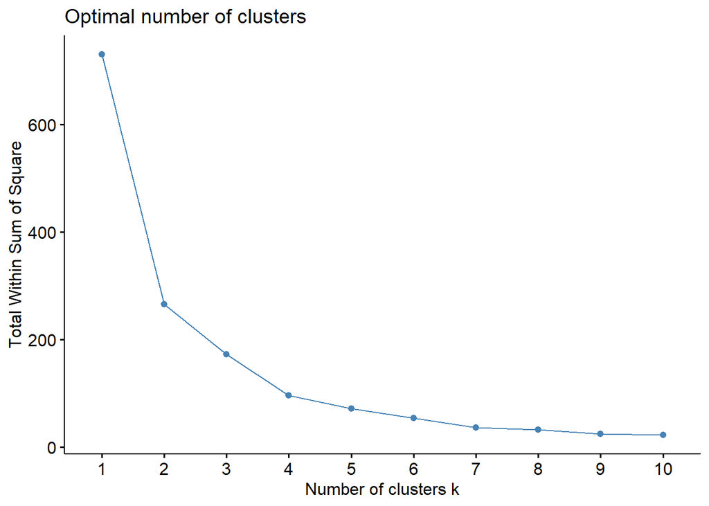

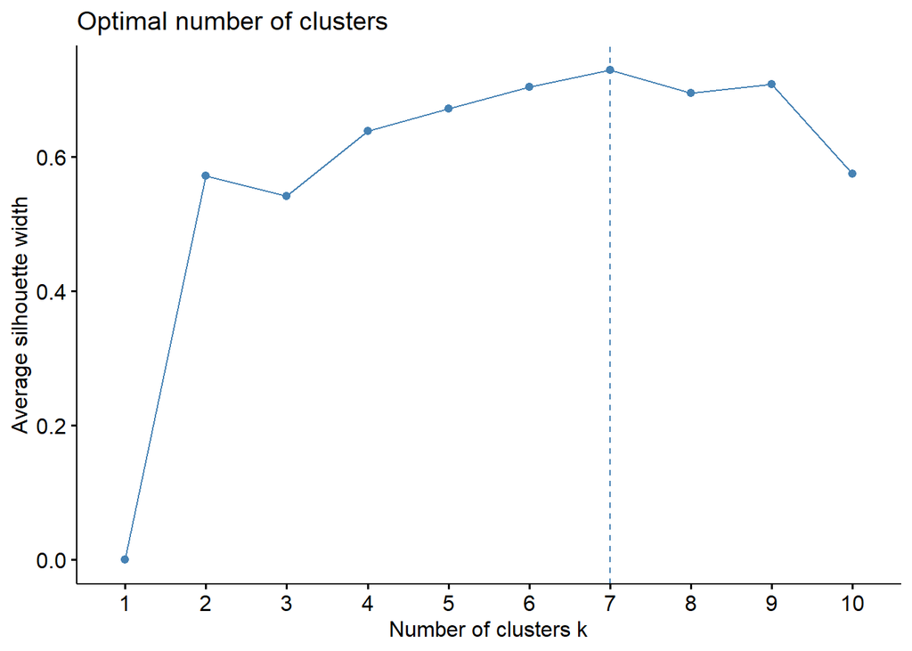

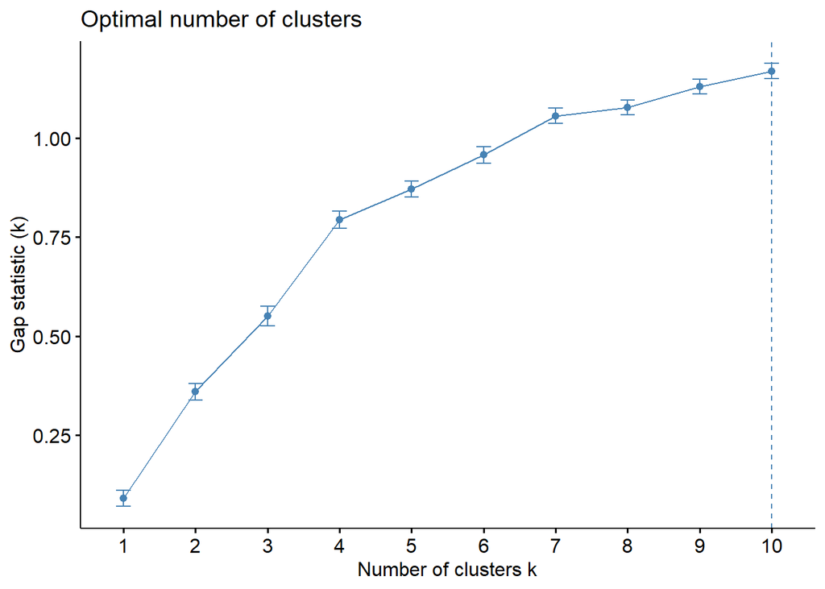

Here, the best $k$ would be probably $k = 7$.

```r
pam_fit <- pam(dist3, k=7, diss = TRUE)
```

And below is a diagram of what the graph looks like with a $7$ cluster split.

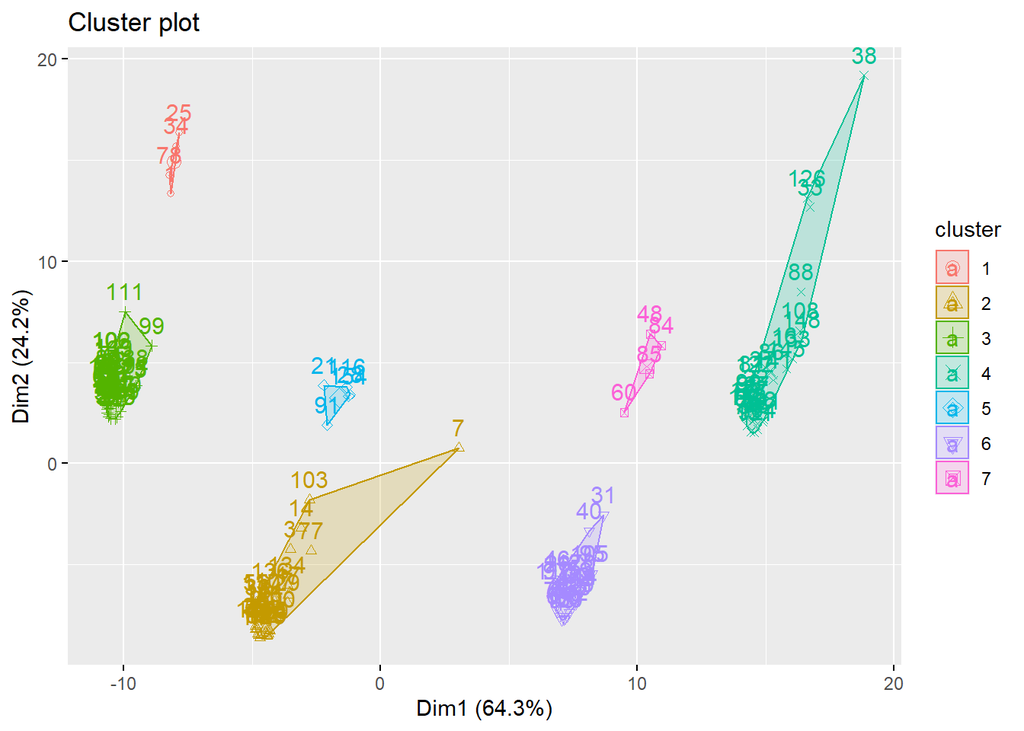

Here the clusters clearly doesn’t overlap and are well separated. It is also possible to check Calinski-Harabasz index (the bigger the better).

```r
calinhara(dist3, pam_fit$cluster)
```

```
## [1] 399.711
```

## 2.4 AGNES

Here, there is no need to specify $k$ value before start of clusterization, but there have to be specified the linkage method (single, complete, average, Ward). To select the best metod, one need to look at the agglomeration coefficient, which measures the amount of cluster structure found (values closer to 1 suggest stronger cluster structures).

```r
m <- c( "single", "average", "complete", "ward")
names(m) <- c( "single", "average", "complete", "ward")
# function to compute aglomeration coefficient
ac <- function(x) {
  agnes(hepatitis.no.labels, method = x, metric = "euclid")$ac
}
map_dbl(m, ac)
```

```
##    single   average  complete      ward
## 0.9341169 0.9665915 0.9854284 0.9942396
```

From the agglomeration coefficient, it is seen that the best is Ward .

```r
agnes.ward <- agnes(hepatitis.no.labels, method = "ward", metric="euclid")
```

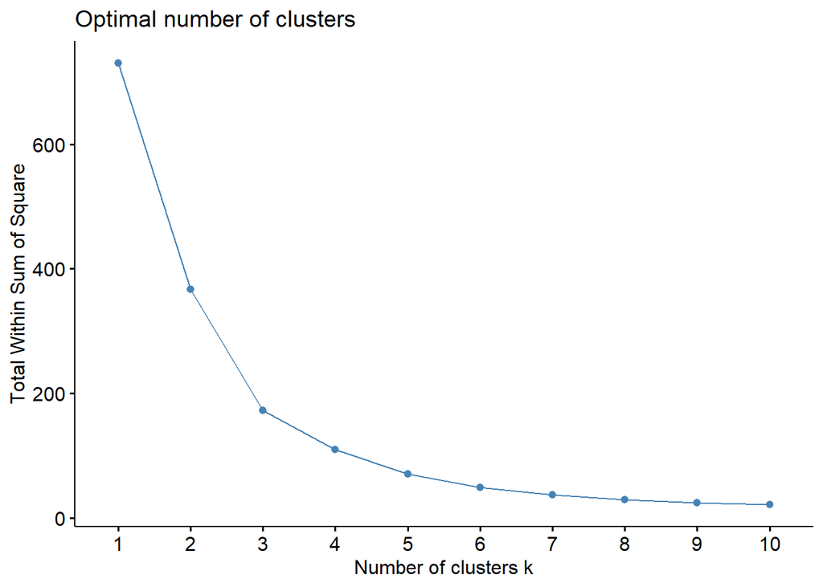

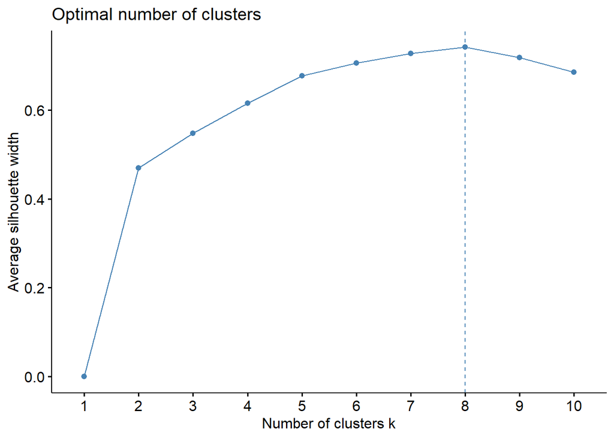

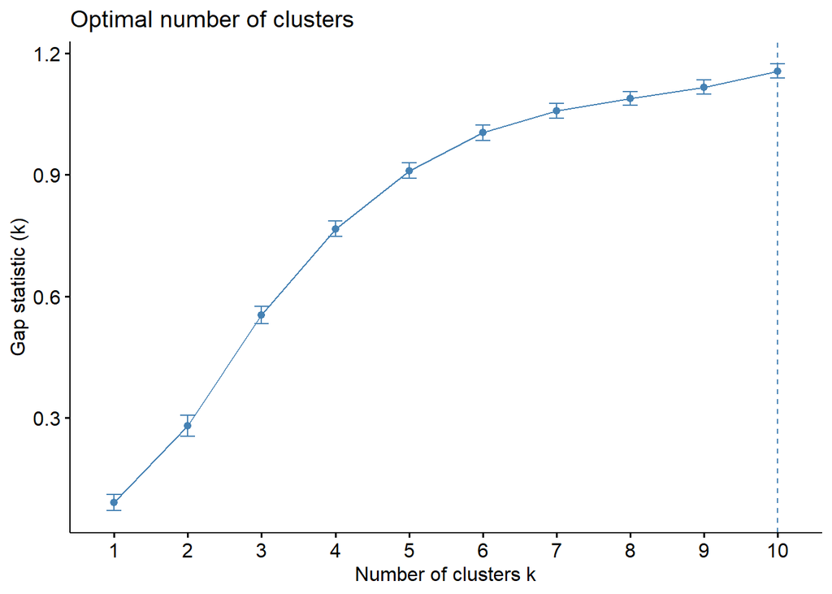

Below is a dendogram and clusters plot.

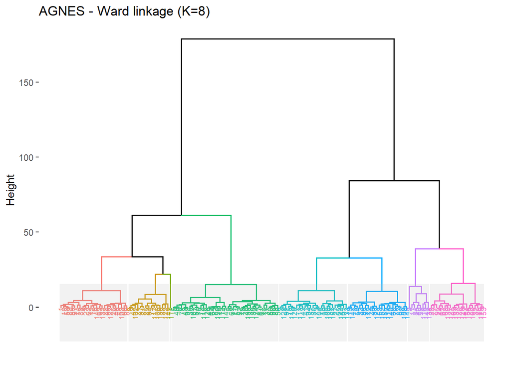

Dendogram and cluster plot for AGNES

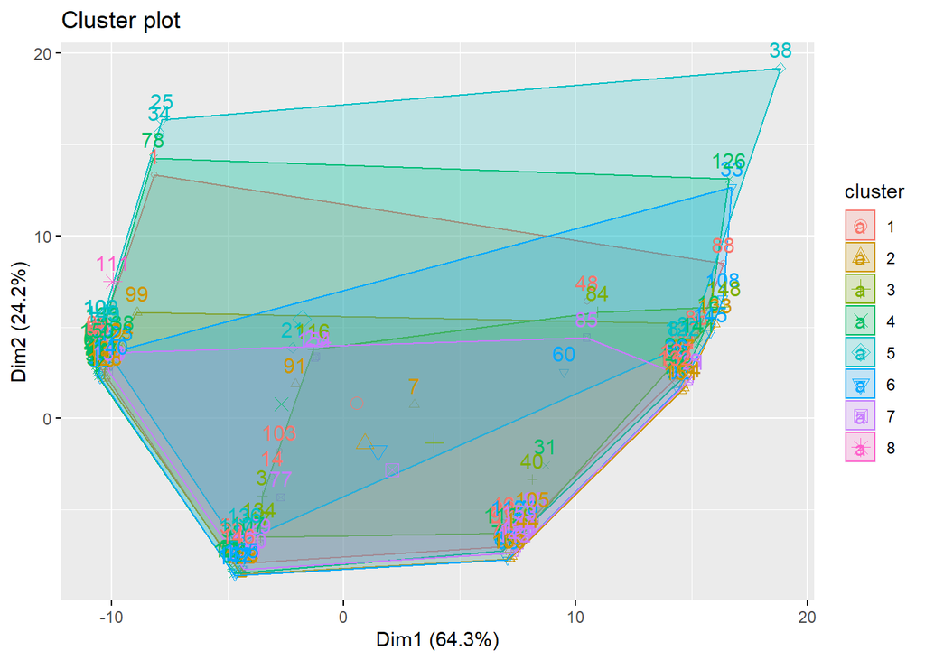

Dendogram and cluster plot for AGNES

Here the cluster plot shows that the clusters are overlapping and clusterization is not too good.

Below there is Calinski-Harabasz index.

```r
calinhara(dist3, clust.agnes)
```

```
## [1] 1.813996
```

## 2.5 DIANA

Here, dissimilarity matrix needs to be used - similar to the PAM algorithm.

```r
diana.mod <- diana(dist3)
```

The divisive coefficient is

```
## [1] 0.9728111
```

The divisive coefficient is quite high. Below there is the dendogram with the division into eight clusters (it is possible to take the same number of clusters as in AGNES).

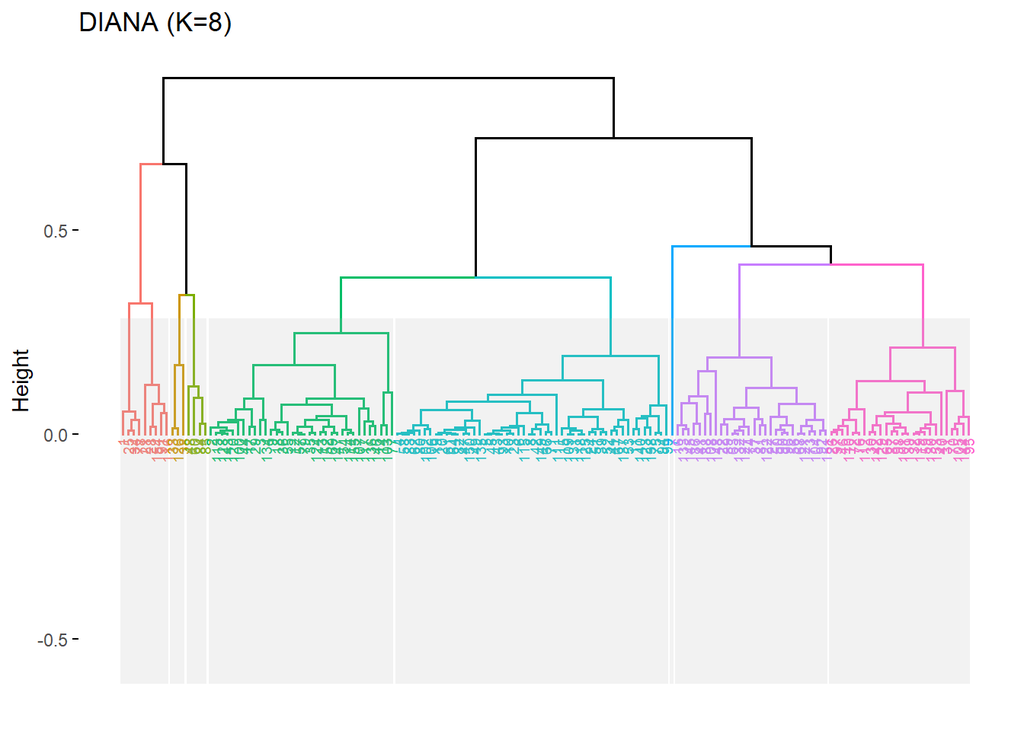

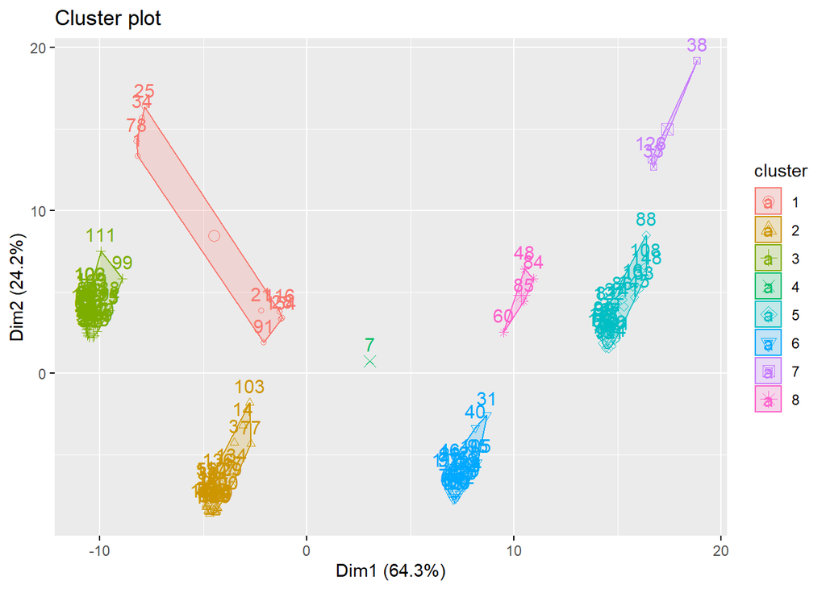

The clusters are very separated from each other.

Below there is Calinski-Harabasz index.

```r
calinhara(dist3, clust.diana.mod)
```

```
## [1] 393.6119
```

## 2.6 K-prototypes

Here, data taken will not be “processed”, but taken without the labels. To find the best value of $k$, Silhouette index, elbow method and McClain index will be shown below in the plots.

```r
k_proto_no_clus <- function(df){

  ind <- numeric(12)
  ind_s <- numeric(12)
  ind_m <- numeric(12)

  for (i in 1:12){
    k_pro <- kproto(df, k = i)

    if (i == 1){
      ind[i] <- 0
      ind_s[i] <- 0
      ind_m[i] <- 0
    }

    else{
      ind[i] <- k_pro$tot.withinss
      ind_s[i] <- validation_kproto(method = "silhouette", object = k_pro)
      ind_m[i] <- validation_kproto(method = "mcclain", object = k_pro)
    }
  }

  par(mfrow=c(2,2))

  plot(2:12, ind[2:12], type = "b", ylab = "Total Within Sum Of Squares", xlab = "Number of clusters")
  plot(2:12, ind_s[2:12], type = "b", ylab = "Silhouette Score", xlab = "Number of clusters")
  plot(2:12, ind_m[2:12], type = "b", ylab = "McClain-Rao index", xlab = "Number of clusters")

}
```

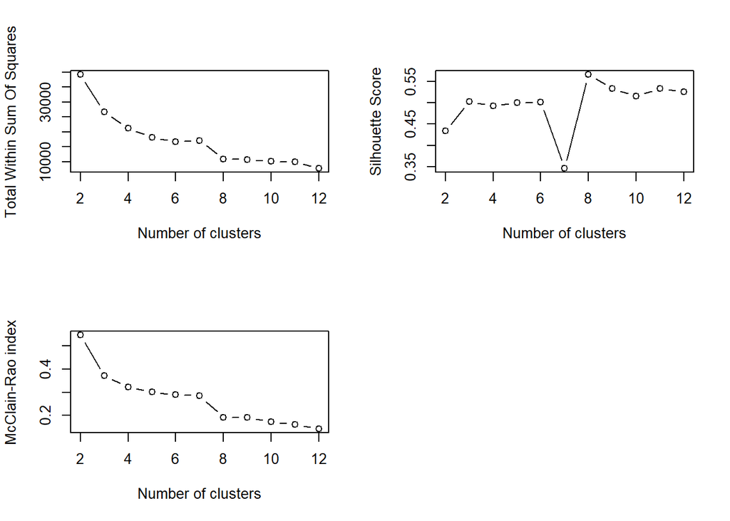

```r
k_proto_no_clus(hepatitis.no.labels)
```

From the elbow method and silhouette score, the best number of cluster should be 8.

```r
k_proto <- kproto(hepatitis.no.labels, k = 8)
```

Below there are centers of all clusters for every variable.

```r
k_proto$centers
```

```
##        AGE SEX FATIGUE MALAISE ANOREXIA BILIRUBIN
## 1 65.15385   M       0       0        1 1.0615385
## 2 27.07143   M       0       0        0 1.2642857
## 3 53.68750   M       0       1        1 1.1250000
## 4 43.78947   M       0       0        0 1.1578947
## 5 48.62500   M       1       1        1 1.0937500
## 6 34.09524   M       0       1        1 1.1047619
## 7 31.28947   M       1       1        1 0.8210526
## 8 43.66667   M       0       0        1 1.1055556
```

Below it is shown in a plots how the clusters look for every variable.

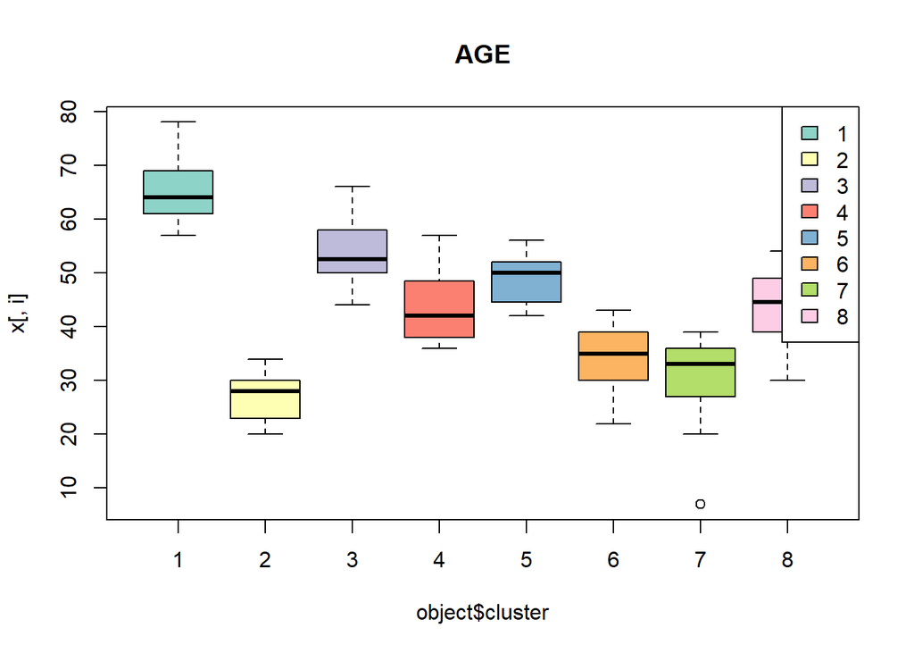

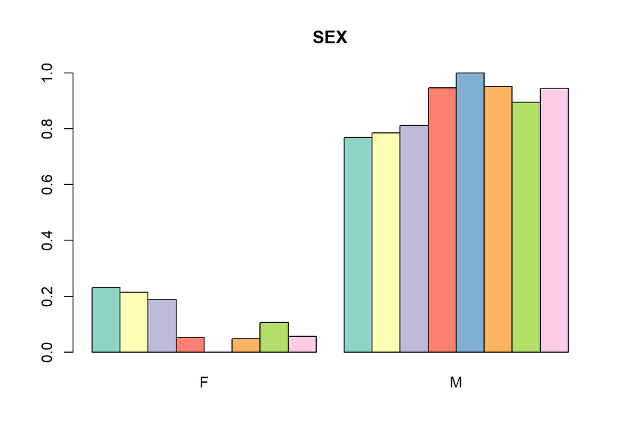

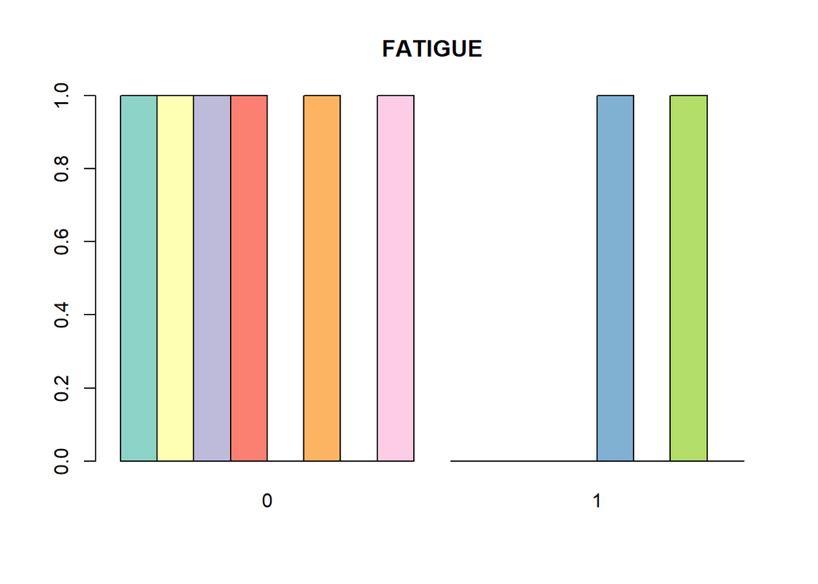

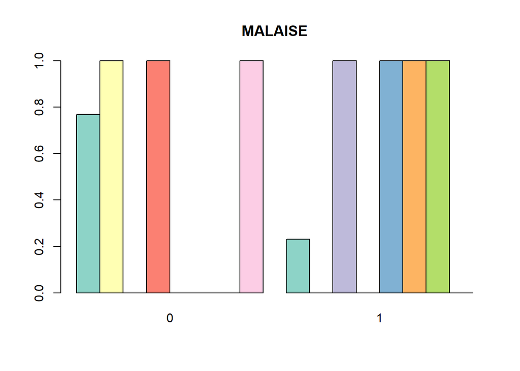

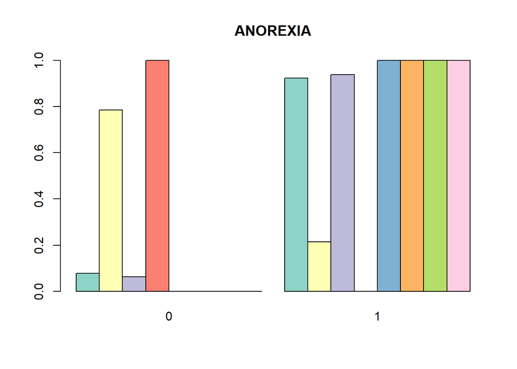

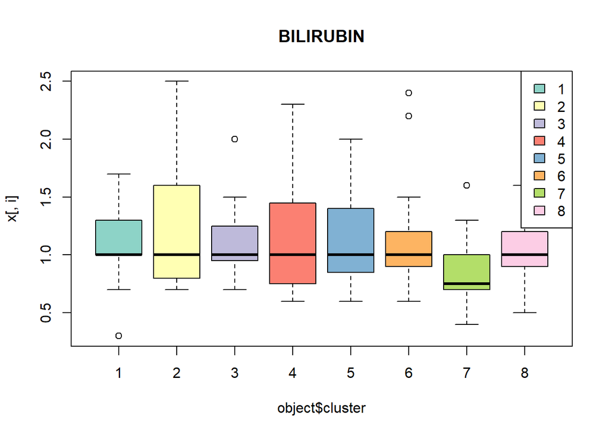

This method has the lowest value of Silhouette score from all the methods presented here.

Below there is Calinski-Harabasz index.

```r
calinhara(dist3, k_proto$cluster)
```

```
## [1] 120.1169
```

By looking only at the Calinski-Harabasz index, the best algorithm for this data is PAM.

# 3 Classification

In this part of the report, the objective is to find a good classifier that classifies patients from our subset into two groups - survival (*LIVE*) and death (*DIE*).

## 3.1 Methods

1. Logistic Regression (LR) - an algorithm otherwise known as a generalised linear model, used to predict the probability of belonging to a class. Logistic regression allows direct assessment of the significance of variables.
2. AdaBoost - this algorithm combine multiple “weak classifiers” into a single “strong classifier”.
3. Classification trees - an algorithm that represents choices and their results in the form of a tree. The nodes in the graph represent the event or choice, and the edges of the graph represent the rules or decision conditions.

## 3.2 Comparison of the classification error using train and test split

In this section of the report, different classification methods will be compared. 3 methods have been used, of which only the most accurate one (i.e. the one for which the classification error was the smallest) will be described. The data has been divided into test and training data, which will be used for all classification models.

```r
n <- nrow(hepatitis1)
learning.indx <- sample(1:n,0.7*n)

learning.set <- hepatitis1[learning.indx,]
test.set <- hepatitis1[-learning.indx,]
```

First, models need to be created and fitted to the data.

```r
# Classification tree

model <- Class~. # all of the variables for creation of the classifiers
n.test <- dim(test.set)[1]

# We build the decision tree (with default parameters)
tree.default <- rpart(model, data=learning.set)

pred.labels.test <- predict(tree.default, newdata=test.set, type = "class")

# determination of projected a posteriori probabilities
pred.probs.test <- predict(tree.default, newdata=test.set, type = "prob")

# Evaluation of classification accuracy

# confusion matrix
conf.mat.test <- table(pred.labels.test, test.set$Class)
error.rate.test <- (n.test - sum(diag(conf.mat.test))) / n.test

sens.tree <- conf.mat.test[2,2]/(conf.mat.test[2,2] + conf.mat.test[2,1])
spec.tree <- conf.mat.test[1,1]/(conf.mat.test[1,1] + conf.mat.test[1,2])
```

```r
# Logistic regression

hepatitis1$Class <- factor(hepatitis1$Class)
learning.set$Class <- factor(learning.set$Class)
test.set$Class <- factor(test.set$Class)

model.logit <- glm(Class~., data = learning.set, family = binomial(link="logit"))

pred.prob <- predict(model.logit, test.set, type = "response")

prob2labels <- function(probs,cutoff)
{
  klasy <- rep("DIE",length(probs))
  klasy[probs>cutoff] <- "LIVE"
  return(as.factor(klasy))
}

# actual and predicted labels
lr.labels <- prob2labels(probs=pred.prob,cutoff=0.35)
real.labels <- test.set$Class

# classification error
conf.matrix <- table(lr.labels, real.labels)
classif.error <- (n.test - sum(diag(conf.matrix)))/n.test

sens.lr <- conf.matrix[2,2]/(conf.matrix[2,2] + conf.matrix[2,1])
spec.lr <- conf.matrix[1,1]/(conf.matrix[1,1] + conf.matrix[1,2])
```

```r
# AdaBoost

model.adaboost <- boosting(Class~., data = learning.set, boos = TRUE, mfinal = 50)

pred.adaboost <- predict.boosting(model.adaboost,newdata = test.set)

# Evaluation of classification accuracy

# confusion matrix
conf.mat.test.ada <- pred.adaboost$confusion
error.rate.test.ada <- pred.adaboost$error

sens.ada <- conf.mat.test.ada[2,2]/(conf.mat.test.ada[2,2] + conf.mat.test.ada[2,1])
spec.ada <- conf.mat.test.ada[1,1]/(conf.mat.test.ada[1,1] + conf.mat.test.ada[1,2])
```

The table below shows the classification error, sensitivity and specificity values for the methods:

- LR,
- AdaBoost,
- classification trees.

Classification error, sensitivity and specificity values

|  | LR | AdaBoost | tree |
| --- | --- | --- | --- |
| Classification error | 0.128 | 0.234 | 0.255 |
| Sensivity | 0.889 | 0.895 | 0.892 |
| Specificity | 0.500 | 0.222 | 0.200 |

It is also possible to see what the ROC curve looks like and how much the area under the curve (AUC) is.

[figure not shown]

```r
true.labels <- test.set$Class

pred.ROCR.logit <- prediction(pred.prob, true.labels)
perf.ROCR.logit <- performance(pred.ROCR.logit, "tpr", "fpr")

pred.ROCR.ada <- prediction(pred.adaboost$prob[,2], true.labels)
perf.ROCR.ada <- performance(pred.ROCR.ada, "tpr", "fpr")

tree.preds <- predict(tree.default, test.set, type="prob")[, 2]
pred.ROCR.tree <- prediction(tree.preds, true.labels)
perf.ROCR.tree <- performance(pred.ROCR.tree, "tpr", "fpr")

plot(perf.ROCR.logit, print.cutoffs.at=seq(0.1, 1, 0.2), colorize=FALSE, col = "green", lwd=2)
plot(perf.ROCR.ada, print.cutoffs.at=seq(0.1, 1, 0.2), colorize=FALSE, col="red", add=T, lwd=2)
plot(perf.ROCR.tree, print.cutoffs.at=seq(0.1, 1, 0.2), colorize=FALSE, col="blue", add=T, lwd=2)

# add the ROC curve for the random classifier
lines(c(0,1), c(0,1), lwd=3, lty=2)
grid()
title("ROC Curve")
legend("bottomright",lty=c(1,1,2), lwd=2, col=c("green","red","blue", "black"),
       legend=c("LR", "AdaBoost", "Decision Tree","Random Classifier"), bg="azure2", cex=0.7)
```

```r
AUC.logit <- performance(pred.ROCR.logit, "auc")@y.values[[1]]
AUC.ada  <- performance(pred.ROCR.ada, "auc")@y.values[[1]]
AUC.tree  <- performance(pred.ROCR.tree, "auc")@y.values[[1]]

df.auc <- data.frame(AUC.logit, AUC.ada, AUC.tree)
colnames(df.auc) <- c("LR", "AdaBoost", "tree")
rownames(df.auc) <- "AUC"

df.auc %>%
  kable(booktabs = TRUE, digits = c(3,3,3), align = "c", caption = "AUC values") %>%
  kableExtra::column_spec(c(2:4), width = "2.5cm") %>%
  kableExtra::column_spec(1, width = "1.5cm") %>%
  kableExtra::kable_styling(latex_options = "HOLD_position")
```

AUC values

|  | LR | AdaBoost | tree |
| --- | --- | --- | --- |
| AUC | 0.785 | 0.663 | 0.636 |

For this dataset, the best classificator is logistic regression.

## 3.3 Description of the selected model

Initially, the model is created on the training data, then the variables relevant to the model are selected - in our case this is age, sex and fatigue (leaving variables irrelevant to the model does not affect the result, although it may lead to overfitting). The model was reduced to the 3 variables mentioned earlier. Below are the output of the reduced model.

```
##
## Call:
## glm(formula = Class ~ AGE + SEX + FATIGUE, family = binomial(link = "logit"),
##     data = learning.set)
##
## Deviance Residuals:
##      Min        1Q    Median        3Q       Max
## -2.67266   0.00002   0.23093   0.79775   1.42353
##
## Coefficients:
##               Estimate Std. Error z value Pr(>|z|)
## (Intercept)   20.43808 1708.22619   0.012  0.99045
## AGE           -0.04541    0.02298  -1.976  0.04813 *
## SEXM         -18.00322 1708.22571  -0.011  0.99159
## FATIGUE1       2.83373    1.05573   2.684  0.00727 **
## ---
## Signif. codes:  0 '***' 0.001 '**' 0.01 '*' 0.05 '.' 0.1 ' ' 1
##
## (Dispersion parameter for binomial family taken to be 1)
##
##     Null deviance: 119.22  on 107  degrees of freedom
## Residual deviance:  89.49  on 104  degrees of freedom
## AIC: 97.49
##
## Number of Fisher Scoring iterations: 17
```

```
##      (Intercept)              AGE             SEXM         FATIGUE1
## "751877083.0288" "        0.9556" "        0.0000" "       17.0088"
```

Below they find a scatter plot and histogram of the predicted logarithms of the odds ratio

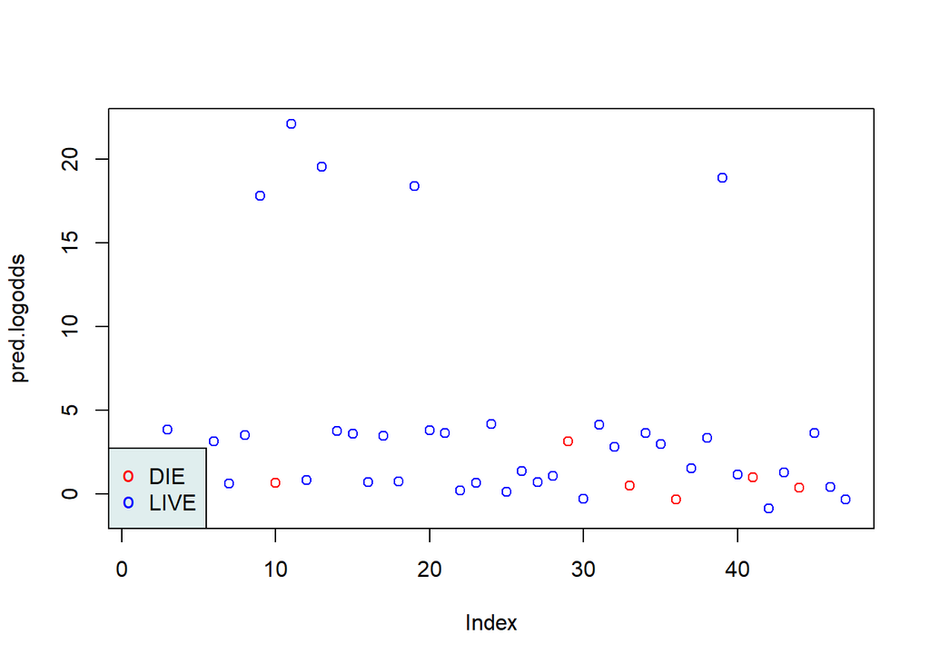

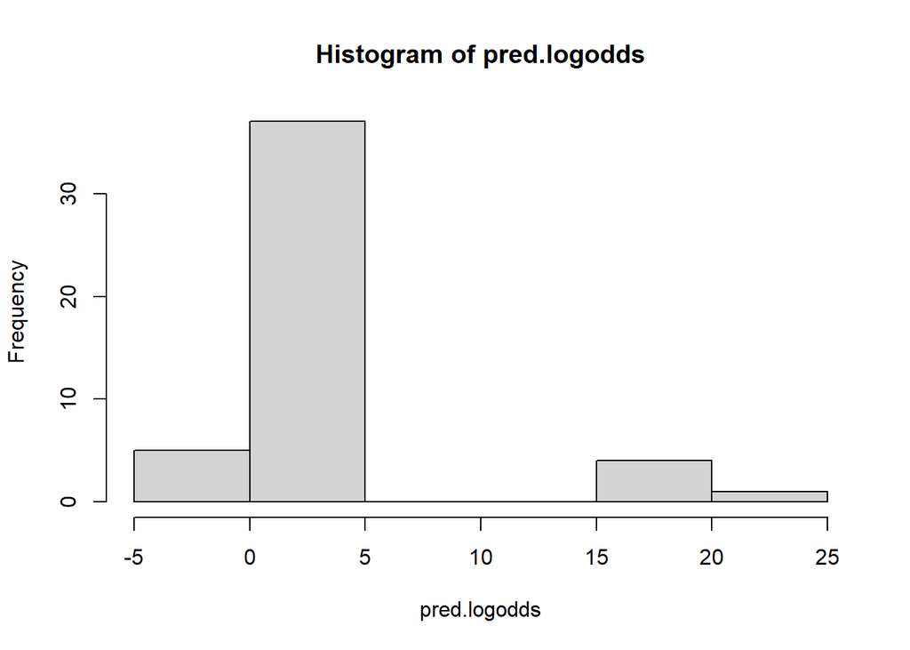

Scatter plot and histogram of predicted odds ratio logarithms

The scatter and histogram of the residuals is as follows:

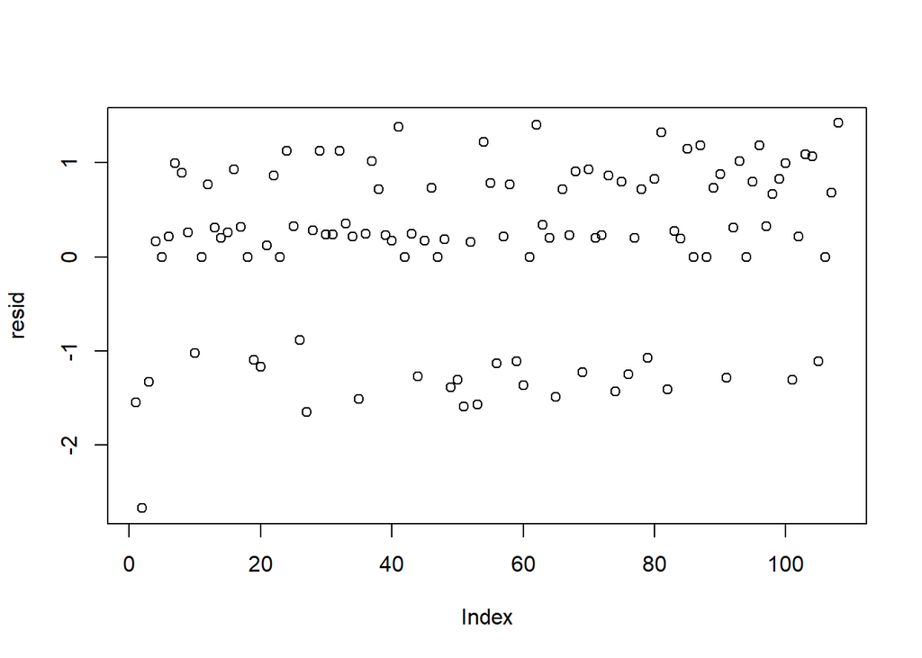

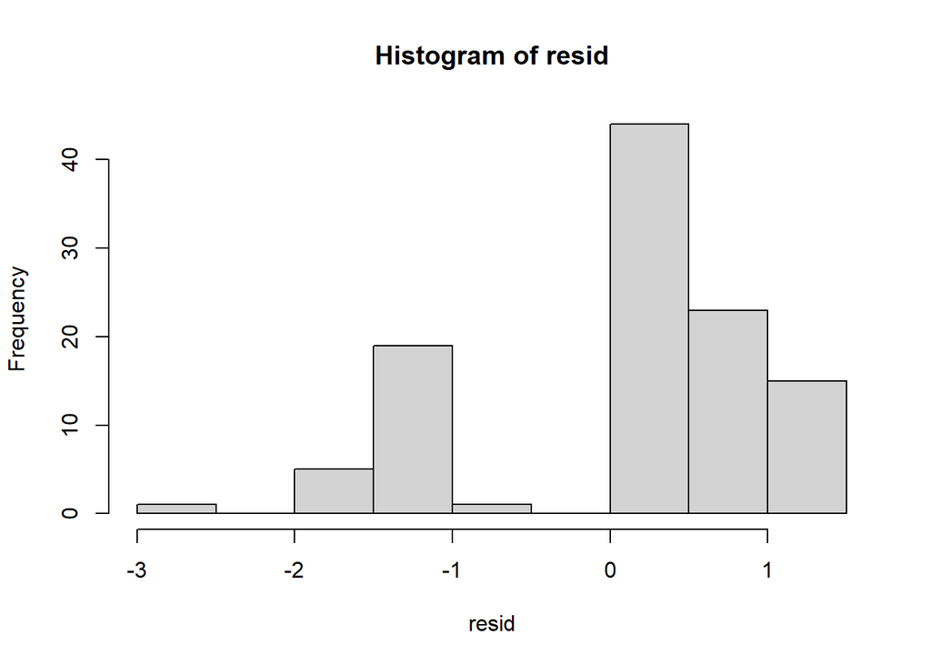

Scatter plot and histogram of residuals

From the scatter plot, it can be seen that most of the residuals are “in one line” - between 0 and 1, which can also be seen in the histogram.